# Impact of Severe Weather Events on Public Health and the Economy in the United States

Alejandro Dominguez

April 17, 2026

## Synopsis

This report analyzes the U.S. National Oceanic and Atmospheric Administration’s (NOAA) storm database to determine which types of severe weather events are most harmful to population health and which have the greatest economic consequences. The dataset spans from 1950 to November 2011 and contains 902,297 records. To assess public health impact, we aggregate fatalities and injuries by event type. For economic impact, we compute total property and crop damage in dollars by converting the damage exponent codes (K, M, B) to their numeric multipliers. Our analysis reveals that **tornadoes** are by far the most dangerous event for population health, causing the most fatalities and injuries combined. In terms of economic damage, **floods** cause the greatest total property and crop losses, followed by hurricanes/typhoons and tornadoes. These findings can help emergency managers prioritize resources for the most destructive event categories.

## Data Processing

We load the raw compressed data file directly (`.csv.bz2`) and select only the columns relevant to our two research questions.

```r
storm <- read.csv("StormData.csv.bz2")
dim(storm)
```

```
## [1] 902297     37
```

The dataset contains 902297 observations and 37 variables. We keep only the columns needed for our analysis: event type, fatalities, injuries, property damage, and crop damage.

```r
cols <- c("EVTYPE", "FATALITIES", "INJURIES", "PROPDMG", "PROPDMGEXP",
          "CROPDMG", "CROPDMGEXP")
storm <- storm[, cols]
str(storm)
```

```
## 'data.frame':    902297 obs. of  7 variables:
##  $ EVTYPE    : chr  "TORNADO" "TORNADO" "TORNADO" "TORNADO" ...
##  $ FATALITIES: num  0 0 0 0 0 0 0 0 1 0 ...
##  $ INJURIES  : num  15 0 2 2 2 6 1 0 14 0 ...
##  $ PROPDMG   : num  25 2.5 25 2.5 2.5 2.5 2.5 2.5 25 25 ...
##  $ PROPDMGEXP: chr  "K" "K" "K" "K" ...
##  $ CROPDMG   : num  0 0 0 0 0 0 0 0 0 0 ...
##  $ CROPDMGEXP: chr  "" "" "" "" ...
```

### Processing Economic Damage

The property and crop damage values are split across two columns each: a numeric value (`PROPDMG`, `CROPDMG`) and an exponent code (`PROPDMGEXP`, `CROPDMGEXP`). The exponent codes represent multipliers: **K** = thousands, **M** = millions, **B** = billions. We convert these to full dollar amounts.

```r
get_multiplier <- function(exp) {
    exp <- toupper(exp)
    mult <- rep(1, length(exp))
    mult[exp == "K"] <- 1e3
    mult[exp == "M"] <- 1e6
    mult[exp == "B"] <- 1e9
    mult[exp == "H"] <- 1e2
    mult[exp %in% as.character(0:9)] <- 10^as.numeric(exp[exp %in% as.character(0:9)])
    mult
}

storm$PROP_TOTAL <- storm$PROPDMG * get_multiplier(storm$PROPDMGEXP)
storm$CROP_TOTAL <- storm$CROPDMG * get_multiplier(storm$CROPDMGEXP)
storm$ECON_TOTAL <- storm$PROP_TOTAL + storm$CROP_TOTAL
```

### Aggregating by Event Type

We aggregate fatalities, injuries, and economic damage by event type.

```r
health <- aggregate(cbind(FATALITIES, INJURIES) ~ EVTYPE, data = storm, sum)
health$HEALTH_TOTAL <- health$FATALITIES + health$INJURIES
health <- health[order(-health$HEALTH_TOTAL), ]

econ <- aggregate(cbind(PROP_TOTAL, CROP_TOTAL, ECON_TOTAL) ~ EVTYPE,
                  data = storm, sum)
econ <- econ[order(-econ$ECON_TOTAL), ]
```

## Results

### Which types of events are most harmful to population health?

We examine the top 10 event types by combined fatalities and injuries.

```r
top_health <- head(health, 10)
top_health[, c("EVTYPE", "FATALITIES", "INJURIES", "HEALTH_TOTAL")]
```

```
##                EVTYPE FATALITIES INJURIES HEALTH_TOTAL
## 834           TORNADO       5633    91346        96979
## 130    EXCESSIVE HEAT       1903     6525         8428
## 856         TSTM WIND        504     6957         7461
## 170             FLOOD        470     6789         7259
## 464         LIGHTNING        816     5230         6046
## 275              HEAT        937     2100         3037
## 153       FLASH FLOOD        978     1777         2755
## 427         ICE STORM         89     1975         2064
## 760 THUNDERSTORM WIND        133     1488         1621
## 972      WINTER STORM        206     1321         1527
```

**Figure 1** shows the top 10 weather event types by total health impact (fatalities + injuries). Tornadoes dominate overwhelmingly, causing over five times more harm than the next event type.

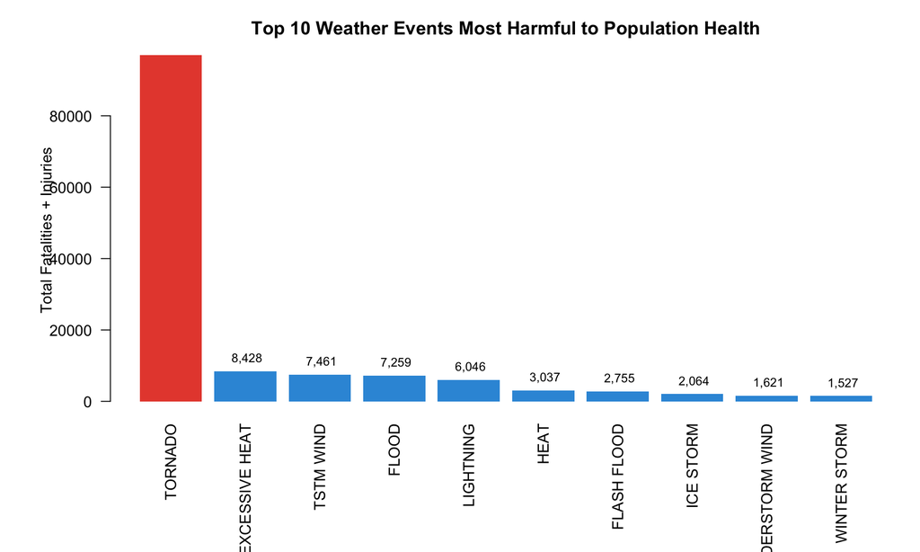

Figure 1: Top 10 weather events most harmful to population health (1950–2011).

```r
par(mar = c(8, 6, 3, 1))
colors <- c("#e74c3c", rep("#3498db", 9))
bp <- barplot(top_health$HEALTH_TOTAL,
              names.arg = top_health$EVTYPE,
              las = 2, col = colors, border = NA,
              main = "Top 10 Weather Events Most Harmful to Population Health",
              ylab = "Total Fatalities + Injuries")
text(bp, top_health$HEALTH_TOTAL, labels = format(top_health$HEALTH_TOTAL, big.mark = ","),
     pos = 3, cex = 0.8)
```

To understand the breakdown between fatalities and injuries, **Figure 2** shows both components side by side for the top 10 events.

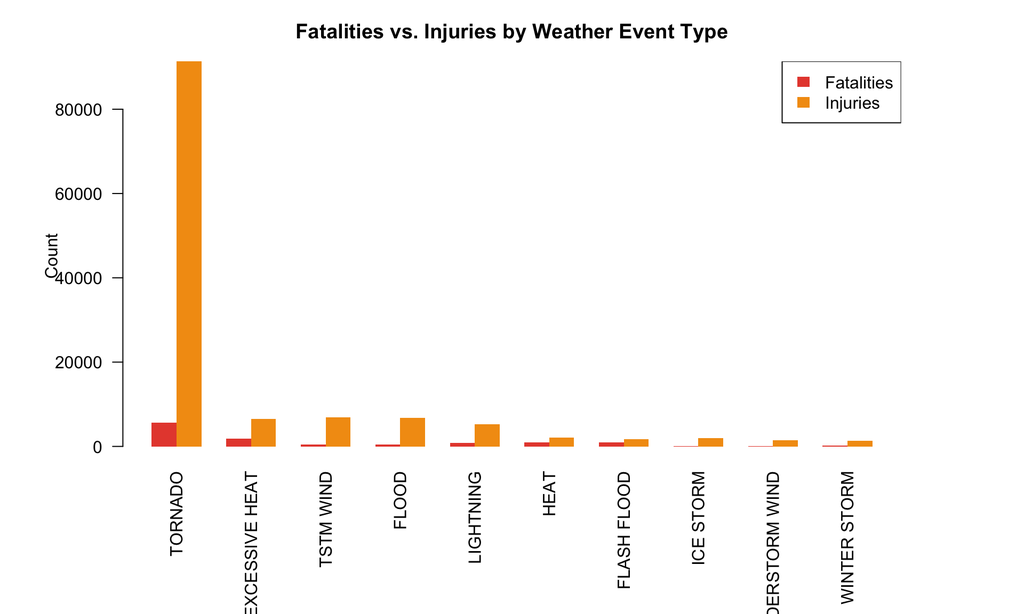

Figure 2: Fatalities vs. injuries for the top 10 most harmful weather events.

```r
par(mar = c(8, 6, 3, 6))
mat <- t(as.matrix(top_health[, c("FATALITIES", "INJURIES")]))
colnames(mat) <- top_health$EVTYPE
barplot(mat, beside = TRUE, las = 2, col = c("#e74c3c", "#f39c12"), border = NA,
        main = "Fatalities vs. Injuries by Weather Event Type",
        ylab = "Count")
legend("topright", legend = c("Fatalities", "Injuries"),
       fill = c("#e74c3c", "#f39c12"), border = NA)
```

Tornadoes cause the most injuries by a wide margin. Excessive heat ranks second for fatalities specifically, highlighting that lethal events are not always the ones causing the most injuries.

### Which types of events have the greatest economic consequences?

We examine the top 10 event types by total economic damage (property + crop).

```r
top_econ <- head(econ, 10)
top_econ$PROP_BILLIONS <- round(top_econ$PROP_TOTAL / 1e9, 2)
top_econ$CROP_BILLIONS <- round(top_econ$CROP_TOTAL / 1e9, 2)
top_econ$TOTAL_BILLIONS <- round(top_econ$ECON_TOTAL / 1e9, 2)
top_econ[, c("EVTYPE", "PROP_BILLIONS", "CROP_BILLIONS", "TOTAL_BILLIONS")]
```

```
##                EVTYPE PROP_BILLIONS CROP_BILLIONS TOTAL_BILLIONS
## 170             FLOOD        144.66          5.66         150.32
## 411 HURRICANE/TYPHOON         69.31          2.61          71.91
## 834           TORNADO         56.95          0.41          57.36
## 670       STORM SURGE         43.32          0.00          43.32
## 244              HAIL         15.74          3.03          18.76
## 153       FLASH FLOOD         16.82          1.42          18.24
## 95            DROUGHT          1.05         13.97          15.02
## 402         HURRICANE         11.87          2.74          14.61
## 590       RIVER FLOOD          5.12          5.03          10.15
## 427         ICE STORM          3.94          5.02           8.97
```

**Figure 3** shows the top 10 event types by total economic damage, split into property and crop components.

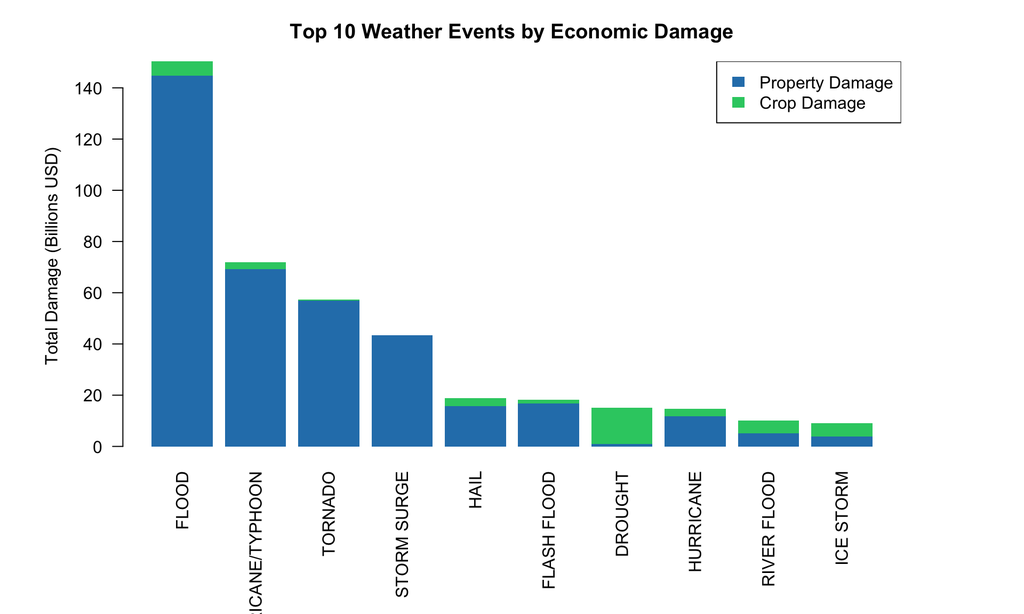

Figure 3: Top 10 weather events with the greatest economic consequences (1950–2011). Damage in billions of USD.

```r
par(mar = c(8, 6, 3, 6))
mat_econ <- t(as.matrix(top_econ[, c("PROP_TOTAL", "CROP_TOTAL")])) / 1e9
colnames(mat_econ) <- top_econ$EVTYPE
barplot(mat_econ, beside = FALSE, las = 2, col = c("#2980b9", "#2ecc71"), border = NA,
        main = "Top 10 Weather Events by Economic Damage",
        ylab = "Total Damage (Billions USD)")
legend("topright", legend = c("Property Damage", "Crop Damage"),
       fill = c("#2980b9", "#2ecc71"), border = NA)
```

Floods cause the greatest total economic damage at over $150 billion, predominantly from property losses. Hurricanes/typhoons rank second, also driven mainly by property damage. Drought, while not among the top property damage events, causes substantial crop losses.

### Summary of Key Findings

| Rank | Most Harmful to Health | Greatest Economic Damage |
| --- | --- | --- |
| 1 | Tornado | Flood |
| 2 | Excessive Heat | Hurricane/Typhoon |
| 3 | TSTM Wind | Tornado |
| 4 | Flood | Storm Surge |
| 5 | Lightning | Hail |

Tornadoes are the most dangerous weather events for population health, while floods impose the heaviest economic burden. Decision-makers should prioritize tornado preparedness for life safety and flood mitigation for economic protection.